# advanced_face_recognition

**Avoiding memory problems**

```python
import os
os.environ['KMP_DUPLICATE_LIB_OK']='True'
```

**Import useful libraries**

```python
from keras.preprocessing.image import ImageDataGenerator #Data Augmentation
from tensorflow.keras import preprocessing #Manage images
from keras.applications import VGG16 #Pre trained image model
from keras.applications.vgg16 import preprocess_input #Preprocessing
from keras.applications.imagenet_utils import decode_predictions #Decoding predictions
from keras.models import Sequential, load_model #Sequential model for a ANN
from keras.layers import Dense, Conv2D, MaxPooling2D, Flatten, Dropout #Importing convolutional 2D, Max pooling 2D, Dense and Flatten layers
from keras.optimizers import Adam #Importing Adam optimizer, it uses variable learning rate and momentum vector
from PIL import Image #Useful image to process images
import pandas as pd #Library to manage dataframes
import matplotlib.pyplot as plt #Library to make plots, etc
from keras.callbacks import ModelCheckpoint #Checkpoint
import numpy as np #Numpy
import warnings
```

**Resizing training images to the same scale in pixels**

```python
directory = os.listdir('./train_original')
for elem in directory:
    original_directory = os.path.join('./train_original/',elem)
    resized_directory = os.path.join('./train_dir/',elem)
    target_size = (224, 224) #Target size needed for VGG16 (224x224 pixels)
    image_files = os.listdir(original_directory)
    for image_file in image_files:
        image_path = os.path.join(original_directory, image_file)
        image = Image.open(image_path)
        resized_image = image.resize(target_size)
        resized_image_path = os.path.join(resized_directory, image_file)
        resized_image.save(resized_image_path)
```

**Resizing validation images to the same scale in pixels**

```python
directory = os.listdir('./validation_original')
for elem in directory:
    original_directory = os.path.join('./validation_original/',elem)
    resized_directory = os.path.join('./validation_dir/',elem)
    target_size = (224, 224) #Target size needed for VGG16 (224x224 pixels)
    image_files = os.listdir(original_directory)
    for image_file in image_files:
        image_path = os.path.join(original_directory, image_file)
        image = Image.open(image_path)
        resized_image = image.resize(target_size)
        resized_image_path = os.path.join(resized_directory, image_file)
        resized_image.save(resized_image_path)
```

**Train an validation directories**

```python
train_directory = './train_dir'
val_directory = './validation_dir'
```

**I'm using Data Augmentation, so I'm configuring the image generator for the training and validation sets**

```python
train_datagen = ImageDataGenerator(
    rescale=1./255,  #Rescaling pixel values to a range of 0 to 1
    shear_range=0.2,  #Applying Random Shear Transformations
    zoom_range=0.2,  # Applying Random Zoom Transformations
    horizontal_flip=True  #Randomly flip images horizontally
)

val_datagen = ImageDataGenerator(rescale=1./255)
```

**Uploading the training and validation images**

```python
train_generator = train_datagen.flow_from_directory(
    train_directory,
    target_size=(224, 224),  #Input image size for VGG16 (224x224 pixels)
    batch_size=32, #Batch size
    class_mode='categorical'  #Categorical classification mode
)

val_generator = val_datagen.flow_from_directory(
    val_directory,
    target_size=(224, 224),  #Input image size for VGG16 (224x224 pixels)
    batch_size=32, #Batch size
    class_mode='categorical'  #Categorical classification mode
)
```

```
Found 28 images belonging to 4 classes.
Found 12 images belonging to 4 classes.
```

**Labels**

```python
labels = dict()
tmp = ["gaby","lliguin","miguel","nube"]
for elem in set(train_generator.labels):
    labels[elem] = tmp[elem]
```

**Using VGG16 that is a pre-trained deep learning model based on CNN, because I don't have a lot of images and I don't want to end up in overfitting**

```python
#Weigths are calculated from trained with ImageNet dataset
#With include_top=False I'm excluding the final layers of VGG16 'cause I've 4 classes and not 1000
#input_shape are the dimensions required for VGG16
vgg16 = VGG16(weights='imagenet', include_top=False, input_shape=(224, 224, 3))
```

**Freezing the weigths of the initial layers of VGG16**

```python
for layer in vgg16.layers:
    layer.trainable = False
```

**Creating the CNN**

```python
cnn = Sequential()
```

**Adding VGG16 layer**

```python
cnn.add(vgg16)
```

**Adding the convolutional layers, the activation function is RELU and the max pooling is used to extract the main features**

```python
cnn.add(Conv2D(64, (3, 3), activation='relu', padding='same'))
cnn.add(Conv2D(32, (3, 3), activation='relu', padding='same'))
cnn.add(MaxPooling2D(pool_size=(2, 2)))
cnn.add(Dropout(0.25))
```

```python
cnn.add(Flatten())
cnn.add(Dense(128, activation='relu'))
cnn.add(Dropout(0.5))
cnn.add(Dense(4, activation='softmax'))
```

**Compiling model**

```python
cnn.compile(optimizer=Adam(learning_rate=0.001), loss='categorical_crossentropy', metrics=['accuracy'])
```

**Checkpoint to save the best model**

```python
checkpoint = ModelCheckpoint('best_cnn.h5', monitor='val_loss',save_best_only=True,mode='min',verbose=1)
```

```python
cnn.fit(train_generator, steps_per_epoch=len(train_generator), epochs=30,validation_data=val_generator,
        validation_steps=len(val_generator),callbacks=[checkpoint])
```

```
Epoch 1: val_loss improved from inf to 1.41432, saving model to best_cnn.h5
Epoch 2: val_loss improved from 1.41432 to 1.33177, saving model to best_cnn.h5
Epoch 3: val_loss did not improve from 1.33177
Epoch 4: val_loss improved from 1.33177 to 1.31961, saving model to best_cnn.h5
Epoch 5: val_loss improved from 1.31961 to 1.29532, saving model to best_cnn.h5
Epoch 6: val_loss improved from 1.29532 to 1.25975, saving model to best_cnn.h5
Epoch 7: val_loss improved from 1.25975 to 1.20047, saving model to best_cnn.h5
Epoch 8: val_loss improved from 1.20047 to 1.10140, saving model to best_cnn.h5
Epoch 9: val_loss improved from 1.10140 to 1.06374, saving model to best_cnn.h5
Epoch 10: val_loss improved from 1.06374 to 1.03784, saving model to best_cnn.h5
Epoch 11: val_loss improved from 1.03784 to 0.98720, saving model to best_cnn.h5
Epoch 12: val_loss improved from 0.98720 to 0.90979, saving model to best_cnn.h5
Epoch 13: val_loss improved from 0.90979 to 0.82059, saving model to best_cnn.h5
Epoch 14: val_loss improved from 0.82059 to 0.73324, saving model to best_cnn.h5
Epoch 15: val_loss improved from 0.73324 to 0.69282, saving model to best_cnn.h5
Epoch 16: val_loss improved from 0.69282 to 0.63778, saving model to best_cnn.h5
Epoch 17: val_loss improved from 0.63778 to 0.58293, saving model to best_cnn.h5
Epoch 18: val_loss improved from 0.58293 to 0.56205, saving model to best_cnn.h5
Epoch 19: val_loss improved from 0.56205 to 0.52957, saving model to best_cnn.h5
Epoch 20: val_loss improved from 0.52957 to 0.48178, saving model to best_cnn.h5
Epoch 21: val_loss improved from 0.48178 to 0.46769, saving model to best_cnn.h5
Epoch 22: val_loss did not improve from 0.46769
Epoch 23: val_loss did not improve from 0.46769
Epoch 24: val_loss did not improve from 0.46769
Epoch 25: val_loss improved from 0.46769 to 0.42125, saving model to best_cnn.h5
Epoch 26: val_loss improved from 0.42125 to 0.35181, saving model to best_cnn.h5
Epoch 27: val_loss improved from 0.35181 to 0.29961, saving model to best_cnn.h5
Epoch 28: val_loss improved from 0.29961 to 0.28403, saving model to best_cnn.h5
Epoch 29: val_loss improved from 0.28403 to 0.27360, saving model to best_cnn.h5
Epoch 30: val_loss improved from 0.27360 to 0.22744, saving model to best_cnn.h5
```

```
<keras.callbacks.History at 0x20e81da63b0>
```

**Plot**

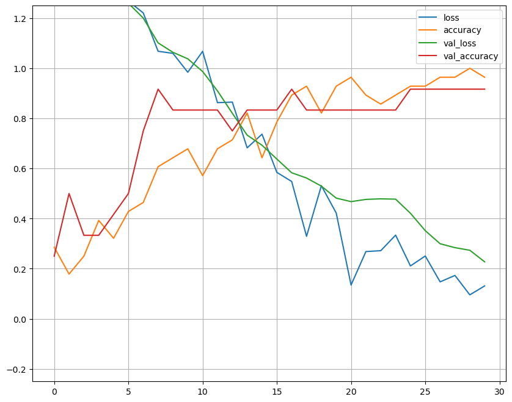

```python
pd.DataFrame(cnn.history.history).plot(figsize=(10,8))
plt.grid(True)
plt.gca().set_ylim(-0.25,1.25)
plt.show()
```

**Evaluating with test images**

```python
best_cnn = load_model('best_cnn.h5')
```

```python
person = input("Insert the name of the file in order to predict it : ")
```

```
Insert the name of the file in order to predict it : imagen4
```

```python
warnings.filterwarnings("ignore")

person = person+".jpeg"

image_test = os.path.join('./test/',person)

img = preprocessing.image.load_img(image_test, target_size=(224, 224), color_mode='rgb')

img_array = preprocessing.image.img_to_array(img)

img_array = img_array.reshape((1, img_array.shape[0], img_array.shape[1], img_array.shape[2]))

img_preprocessed = preprocess_input(img_array)

preds = best_cnn.predict(img_preprocessed)

max_index = np.argmax(preds)

print("Person is : " + labels[max_index])
```

```
Person is : gaby
```